# What makes Canadians rate their life: life feeling rating analysis

Man Fei, 1002129984

2020/12/21

## Abstract

It is important to have a good feeling towards one’s life. In this report, GSS data [1] is used to find out if happiness (Feelings_life in GSS) for Canadian relates to their financial situation, education level, family situation(marriage, children), mental & physical health, and sex. The data is from the 2017 Canadian General Social Survey [1]. Multiple linear relationship between Canadians’ Feelings_life, and 10 different predictor variables are the interest for this report. To build more complex linear models, powers, logs and reciprocal transformation and AIC elimination are used to get a final model (model 3). Significance of the model is discussed, and in the next steps more methods can be used to get more complete model.

## Key words

Feeling life, Rating, Observational Study, Multiple Linear Regression, Satisfaction

## Introduction

One’s degree of satisfaction towards life is very important for people. It is essential because this greatly determines one’s happiness and fulfillment in life. Satisfaction on life can be affected by many things. For example, one’s economic standing affect his satisfaction towards life. If one spends more time on trying to make more money, there is less time foe him to spend time on what he likes. Another example could be marital status can affect one’s feeling for life. Different marital status gives a person different sense of belonging, loneliness, or freedom etc, and all these feelings can affect people’s feeling towards life.

Multiple Linear Regression can be a good way to find out the correlation between feeling towards life and other aspects in life. It can model correlations between more than two variables, which is suitable for this circumstance [2]. Observational data can be put into MLR model to find out if there is multiple linear relationship [2], and further transformations of data can also be done.

This report continue exploring GSS data to find out if happiness (Feelings_life in GSS) for Canadian relates to their financial situation, education level, family situation(marriage, children), mental & physical health, sex, and ages. The data is the dataset from the 2017 Canadian General Social Survey (Cycle 31, Family) [1]. To continue from a less-than-perfect report [3], further exploration is needed on whether there is a multiple linear relationship between Canadians’ Age, Feelings_life, age_at_first_birth, sex, marital_status, education, income_family, average_hours_worked, self_rated_health, and self_rated_mental_health, adding two more variables age_youngest_child_under_6 and total_children. In addition to the former project [3], a more significant model is built by more complex linear models. Box-Cox transformation [4], AIC backward elimination [5] are implemented. Results show that some variable (age) is not as significant as others. The final model has a higher $R^2$ compared to former model, making it more significant in predicting life satisfaction feeling.

## Methodology

Code and data supporting this analysis is available at: “https://github.com/Feymann7/STA304-final-project”

DATA  
Table 1: all data

|  | age | age_at_first_birth | feelings_life | sex | marital_status | education | income_family | average_hours_worked | self_rated_health | self_rated_mental_health | age_youngest_child_under_6 | total_children |
| --- | --- | --- | --- | --- | --- | --- | --- | --- | --- | --- | --- | --- |
| 1 | 26.8 | 18.8 | 10 | Female | Living common-law | Trade certificate or diploma | $75,000 to $99,999 | 30.0 to 40.0 hours | Very good | Very good | 5 | 2 |
| 2 | 37.0 | 35.4 | 9 | Female | Living common-law | University certificate or diploma below the bachelor's level | $100,000 to $ 124,999 | 30.0 to 40.0 hours | Excellent | Excellent | 1 | 1 |
| 3 | 68.9 | 32.8 | 10 | Male | Married | Bachelor's degree (e.g. B.A., B.Sc., LL.B.) | $100,000 to $ 124,999 | 40.1 to 50.0 hours | Excellent | Excellent | 5 | 4 |
| 4 | 34.5 | 32.8 | 7 | Male | Single, never married | Bachelor's degree (e.g. B.A., B.Sc., LL.B.) | $50,000 to $74,999 | 30.0 to 40.0 hours | Good | Very good | 1 | 1 |
| 5 | 31.5 | 30.4 | 9 | Female | Living common-law | Bachelor's degree (e.g. B.A., B.Sc., LL.B.) | $75,000 to $99,999 | 0.1 to 29.9 hours | Very good | Very good | 1 | 1 |
| 6 | 41.4 | 35.8 | 7 | Female | Married | University certificate, diploma or degree above the bach... | $125,000 and more | 30.0 to 40.0 hours | Good | Very good | 2 | 2 |

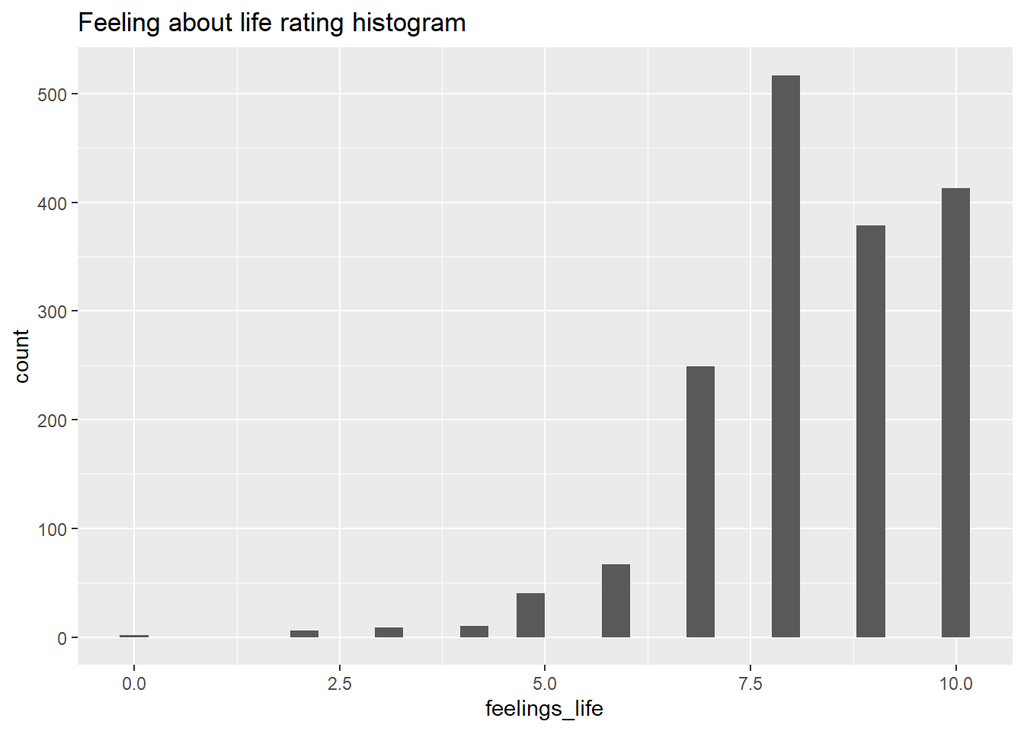

MODEL

For my initial model 1, I run a multiple linear regression through all variables, using feelings_life as the response variable, and age, age_at_first_birth, feelings_life, sex, marital_status, education, income_family, average_hours_worked, self_rated_health, self_rated_mental_health, age_youngest_child_under_6, total_children as the predictors. The p-value for the global F-test is <2.2e-16, and the $R^2 = 0.3187$. This the a rather significant result for such large data set.

However, I try to improve the model by Box-Cox Transformation [4]. After I transform variables using Box-Cox transformation, I find out the $R^2$ is the same as model 1, but model 2 is more complicated in formula. So the original model 1 is retained. I observe the data p-values and find out that although the global F-test is significant for model 1, some individual tests fail. For example, the p-value for self_rated_mental_healthPoor is insignificant while other categories for the same variable is significant. Based on this, I create a new model 3 using AIC elimination [5] to solve this.

After age is deleted from the linear model, Model 3 is the final model. The linear regression of model 3 is $y = \beta_{0} + \beta_{1}x_1 +\beta_{2}x_2 + \beta_{3}x_3 +\beta_{4}x_4 + \beta_{5}x_5 +\beta_{6}x_6 + \beta_{7}x_7 +\beta_{8}x_8 + \beta_{9}x_9 + \beta_{10}x_{10}$, where y = feeling_life which is the response variable, $x_1$ - $x_9$ are predictor variables, $x_1$ = age_at_first_birth, $x_2$ = sex, $x_3$ = average_hours_worked, $x_4$ = marital_status, $x_5$ = education, $x_6$ = income_family, $x_7$ = self_rated_health, $x_8$ = self_rated_mental health, $x_9$ = age_youngest_child_under_6, $x_{10}$ = total_children. The final model 3 has the smallest AIC = 628.28 and the simplest predictor variable constitutions, for response variable feelings_life.

# Results

The final model has intercept and estimated slopes as shown in the following table. The model $y = \beta_{0} + \beta_{1}x_1 +\beta_{2}x_2 + \beta_{3}x_3 +\beta_{4}x_4 + \beta_{5}x_5 +\beta_{6}x_6 + \beta_{7}x_7 +\beta_{8}x_8 + \beta_{9}x_9 + \beta_{10}x_{10}$. $\hat\beta_{0} = 2.856259$, this is our intercept, with p-value 0.143990. Variable age_at_first_birth has slope estimate $\hat\beta_{1} =-0.026223$, with p-value = 0.000113. This means with 1 unit increase in age_at_first_birth, holding other variables constant, feeling_life is expected to decrease 0.026223. Categorical variable $\beta_2$ has slope estimate $\beta_{sexMale}$ = -0.219246. This means when sex is female, this term is 0, while when sex is male, the slope estimate is -0.219246. And the p-value is 0.001011< 0.05, which is significant.
$$\begin{equation}
\hat\beta_{2} =
\begin{cases}
\beta_{sexMale} = -0.219246 & \text{if sex is male}\\
0 & \text{if sex is female}
\end{cases}
\end{equation}$$
Similarly, the estimated slopes for $\beta_{3}$ to $\beta_{10}$ are illustrated as follows, respectively for average_hours_worked, marital_status, education, income_family, self_rated_health, self_rated_mental_health:
$$\begin{equation}
\hat\beta_{3} =
\begin{cases}
\beta_{\text{average_hours_worked0.1 to 29.9 hours}} = 1.831046 & \text{if average hours worked is 0.1-29.9 hours}\\
\beta_{\text{average_hours_worked30.0 to 40.0 hours}}= 1.973047 & \text{if average hours worked is 30-40 hours}\\
\beta_{\text{average_hours_worked40.1 to 50.0 hours} }= 2.117700 & \text{if average hours worked is 40.1-50 hours}\\
\beta_{\text{average_hours_worked50.1 hours and more} }= 2.157288 & \text{if average hours worked is 50.1 and more hours}\\
\beta_{\text{average_hours_workedDon't know}} = 1.343838 & \text{if average hours worked is not known}\\
0 & \text{if average hours worked is less than 0.1 hours}
\end{cases}
\end{equation}$$

$$\begin{equation}
\hat\beta_{4} =
\begin{cases}
\beta_{\text{marital_statusLiving common-law}} = -0.545830 & \text{if marital status is having living common-law partner}\\
\beta_{\text{marital_statusMarried}} = -0.462328 & \text{if marital status is married}\\
\beta_{\text{marital_statusSeparated}} = -1.177676 & \text{if marital status is separated}\\
\beta_{\text{marital_statusSingle, never married}} = -1.096904 & \text{if marital status is single and never married}\\
\beta_{\text{marital_statusWidowed}} = -0.609398 & \text{if marital status is widowed}\\
0 & \text{if marital status is other}
\end{cases}
\end{equation}$$

And $\hat\beta_{9} = -0.043339$, which is the estimated slope for age_youngest_child_under_6, with p-value = 0.019520 < 0.05, which is significant. $\hat\beta_{10} = 0.054027$, which is the estimated slope for total_children, with p-value = 0.102176 > 0.05. All slope estimators and corresponding p-values are listed in the table below.  
Table 2: Slope estimates and p-values for predictors

```
##                                                                        estimated regression coefficient
## Intercept                                                              2.856259
## age_at_first_birth                                                     -0.026223
## sexMale                                                                -0.219246
## average_hours_worked0.1 to 29.9 hours                                  1.831046
## average_hours_worked30.0 to 40.0 hours                                 1.973047
## average_hours_worked40.1 to 50.0 hours                                 2.117700
## average_hours_worked50.1 hours and more                                2.157288
## average_hours_workedDon't know                                         1.343838
## marital_statusLiving common-law                                        -0.545830
## marital_statusMarried                                                  -0.462328
## marital_statusSeparated                                                -1.177676
## marital_statusSingle, never married                                    -1.096904
## marital_statusWidowed                                                  -0.609398
## educationCollege, CEGEP or other non-university certificate or diploma 0.143529
## educationHigh school diploma or a high school equivalency certificate  0.193145
## educationLess than high school diploma or its equivalent               0.527132
## educationTrade certificate or diploma                                  0.151863
## educationUniversity certificate or diploma below the bachelor's level  0.294567
## educationUniversity certificate, diploma or degree above the bachelor  0.020526
## income_family$125,000 and more                                         0.199942
## income_family$25,000 to $49,999                                        -0.166061
## income_family$50,000 to $74,999                                        0.042703
## income_family$75,000 to $99,999                                        -0.022085
## income_familyLess than $25,000                                         -0.106366
## self_rated_healthExcellent                                             1.050221
## self_rated_healthFair                                                  0.186045
## self_rated_healthGood                                                  0.810536
## self_rated_healthPoor                                                  0.047775
## self_rated_healthVery good                                             0.829585
## self_rated_mental_healthExcellent                                      4.478973
## self_rated_mental_healthFair                                           2.406130
## self_rated_mental_healthGood                                           3.387906
## self_rated_mental_healthPoor                                           0.389899
## self_rated_mental_healthVery good                                      4.036514
## age_youngest_child_under_6                                             -0.043339
## total_children                                                         0.054027
##                                                                        p-value
## Intercept                                                              0.143990
## age_at_first_birth                                                     0.000113
```

[output cut: 19 more lines]

```
## income_family$50,000 to $74,999                                        0.675807
## income_family$75,000 to $99,999                                        0.822683
## income_familyLess than $25,000                                         0.545458
## self_rated_healthExcellent                                             0.381120
## self_rated_healthFair                                                  0.877529
## self_rated_healthGood                                                  0.498609
## self_rated_healthPoor                                                  0.969592
## self_rated_healthVery good                                             0.488721
## self_rated_mental_healthExcellent                                      0.000205
## self_rated_mental_healthFair                                           0.046924
## self_rated_mental_healthGood                                           0.004880
## self_rated_mental_healthPoor                                           0.754387
## self_rated_mental_healthVery good                                      0.000808
## age_youngest_child_under_6                                             0.019520
## total_children                                                         0.102176
```

# Discussion

SUMMARY  
Multiple Linear Regression is modeled to the data, and three models are used to find out the correlations between feelings_life and age, age_at_first_birth, sex, marital_status, education, income_family, average_hours_worked, self_rated_health, and self_rated_mental_health, age_youngest_child_under_6 and total_children. My first model is the original multiple linear model for all the variables, and second model is a model using Box-Cox transformation, and the third model is the model obtained by AIC elimination. Model 3 is the best model I get so far. Slope estimates and p-values are presented in Table 2.

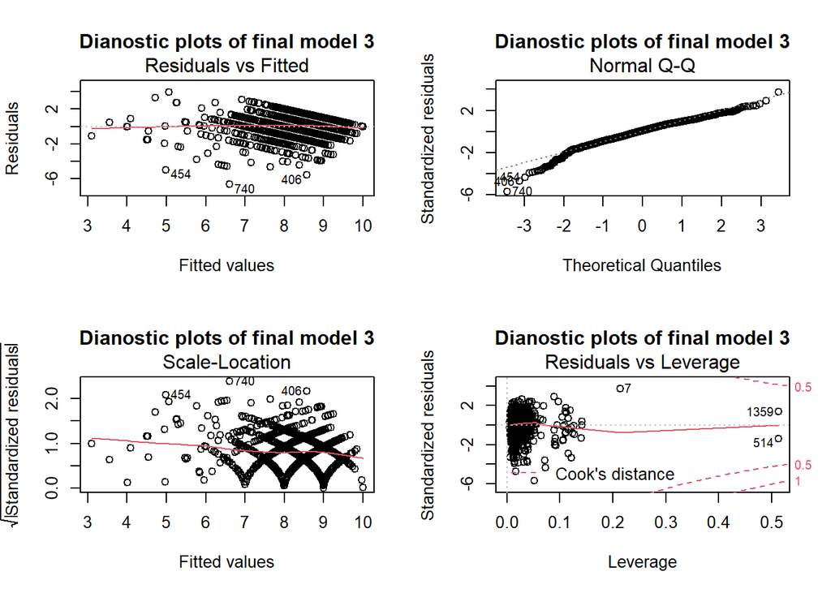

The weakness of this analysis is that numerical variables are mostly discrete variables, which are not as representative as continuous variables. Another weakness is that categorical variables are hard to visually represented, making it hard to make any graphs from analysis. A disadvantage on the data itself is that the data is observational data instead of causal data. This makes it impossible to draw results that is causal, so the conclusions in this analysis are all on correlations between variables.  
A future step for the analysis is to do weight least square analysis. Clearly some variables (for example, self_rated_mental_health) are more important than others, so it should be weighted more than others. Weighted Least Square regression model can build better model to predict life feelings.

# References

[1] General Social Survey (GSS), Cycle 31, 2017: Family. Retrieved December 18 2020, from http://www.chass.utoronto.ca  
[2] Multiple Linear Regression. (2020). Retrieved December 18 2020, from http://www.stat.yale.edu/Courses/1997-98/101/linmult.htm  
[3] What Makes Canadian Rate Their Feelings of Life. STA304, Winter 2020. Yiwen Feng, Yutong Yuan, Sirui Xu, Man Fei, University of Toronto.  
[4] Box Cox Transformation. Retrived December 22, 2020 from https://www.statisticshowto.com/box-cox-transformation/  
[5] Variable Selection. Retrieved on December 22, 2020, from http://www.biostat.jhsph.edu/~iruczins/teaching/jf/ch10.pdf